# BycatchEstimatorStan User Guide

Elizabeth A. Babcock

2026-09-07

This library runs a Bayesian version of the model-based bycatch estimation procudure in the library BycatchEstimator. See the BycatchEstimator User’s Guide for how to set up the data at https://ebabcock.github.io/BycatchEstimator/. The source code is at https://github.com/ebabcock/BycatchEstimatorStan and the User’s Guide for the Bayesian version is at https://ebabcock.github.io/BycatchEstimatorStan/.

The code requires either cmdstanr (Gabry et al. (2025)) or rstan (Stan Development Team (2025)) to run the MCMC algorithm, preferably cmdstanr. You must install cmdstanr before you install BycatchEstimatorStan, following the instructions here https://mc-stan.org/cmdstanr/.

To install BycatchEstimatorStan, use the following code:

```r
# install.packages("pak")
pak::pak("ebabcock/BycatchEstimator")
```

```
## ℹ Loading metadata database✔ Loading metadata database ... done
##
## → Package library at 'C:\Users\babco\AppData\Local\R\win-library\4.6'.
## ℹ No downloads are needed
## ✔ 1 pkg + 177 deps: kept 178 [11s]
```

```r
pak::pak("ebabcock/BycatchEstimatorStan")
```

[output not shown]

Open all the libraries

```r
library(BycatchEstimator)
library(BycatchEstimatorStan)
```

### Model bycatch rate

Run with example data from BycatchEstimator

```r
obsdat<-droplevels(LLSIM_BUM_Example_observer[LLSIM_BUM_Example_observer$Year>2014 &LLSIM_BUM_Example_observer$fleet==2,])
logdat<-droplevels(LLSIM_BUM_Example_logbook[LLSIM_BUM_Example_logbook$Year>2014 & LLSIM_BUM_Example_logbook$fleet==2,])
setupObjBUM<-bycatchSetup(
  obsdat = obsdat,
  logdat = logdat,
  yearVar = "Year",
  obsEffort = "sets",
  logEffort = "sets",
  factorVariables = c("Year","area"),
  numericVariables = NA,
  EstimateBycatch = TRUE,
  logNum = NA,
  sampleUnit = "trips",
  baseDir = getwd(),
  runName = "LLSIMBUMtripExample",
  runDescription = "LLSIm BUM by trip, with 5% observer coverage",
  common = "Blue marlin",
  sp = "Makaira nigricans",
  obsCatch ="BUM",
  catchUnit = "number",
  catchType = "catch",
  reportType = "html"
)
```

Look at the output html file to see whether there are any problems with your data setup.

Now run BycatchStan

```r
modelsToRun<-c("y~Year","y~1")
useCode="cmdstanr"
BUMRun<-bycatchStanSim(setupObjBUM,
                        modelsToRun=modelsToRun,
                        spNum=1,  #which species to run in input is multispecies
                        modeledEffort=FALSE,
                        priors =  list(interceptSD=10,
                                      coefficientSD=1,
                                      phiType=c("exponential","normal")[1],
                                      phiPar=1),
                        StanOutDir=NULL,  #Null to use base directory from SetupObj
                        useCode=useCode)
```

```
## Running MCMC with 4 chains, at most 8 in parallel...
##
## Chain 1 finished in 1.5 seconds.
## Chain 2 finished in 1.5 seconds.
## Chain 3 finished in 1.5 seconds.
## Chain 4 finished in 1.5 seconds.
##
## All 4 chains finished successfully.
## Mean chain execution time: 1.5 seconds.
## Total execution time: 1.8 seconds.
```

```
## Running MCMC with 4 chains, at most 8 in parallel...
##
## Chain 4 finished in 0.8 seconds.
## Chain 1 finished in 0.9 seconds.
## Chain 2 finished in 0.9 seconds.
## Chain 3 finished in 0.9 seconds.
##
## All 4 chains finished successfully.
## Mean chain execution time: 0.8 seconds.
## Total execution time: 1.1 seconds.
```

The bycatchStanSim function prints its output to an rds file, so you can read it back in later to make plots and look at diagnostics.

```r
#Specify directory with bycatch Estimator results
outDir<-setupObjBUM$bycatchInputs$outDir
# Date of bycatch estimator run
estimatorDate<-Sys.Date()
# Date of stan run
stanDate<-Sys.Date()
# Read in bycatchEstimator setup
setupObj<-readRDS(paste0(outDir,"/",estimatorDate,"_BycatchSetupSpecification.rds"))
spNum<-1
#Stan output directory
StanOutDir<-paste0(outDir,"/","Bluemarlincatch")
# Read in stan run summary files
stanSum<-readRDS(paste0(StanOutDir,
                         "/STAN",stanDate,"StanOutputs.rds"))
```

The following code takes either the output that was just read in or the outputs from this section and looks at more diagnostics.

```r
#Choose outputs to use
stanSum<-BUMRun
setupObj<-setupObjBUM
```

Plot the annual bycatch estimates

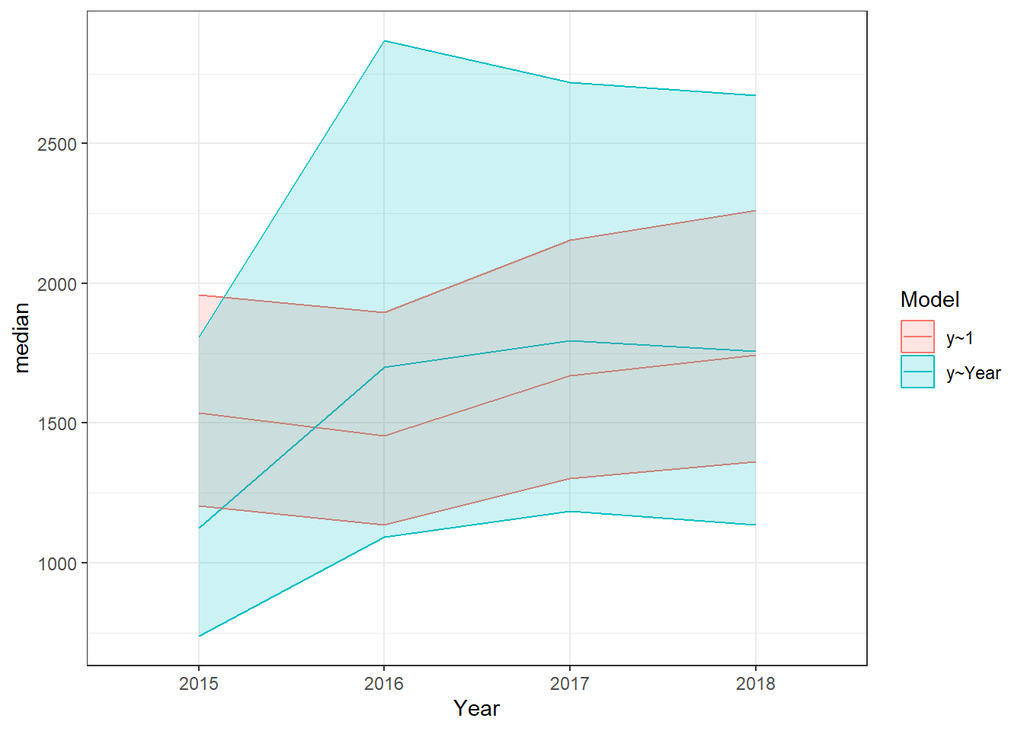

```r
plotStan(stanSum$yearSum)
```

Here is the model selection table

```r
stanSum$waictab
```

```
## # A tibble: 2 × 7
##   Model   waic looic numHighK  maxK Dwaic Dlooic
##   <chr>  <dbl> <dbl>    <dbl> <dbl> <dbl>  <dbl>
## 1 y~Year  563.  563.        0 0.472  2.93   3.03
## 2 y~1     560.  560.        0 0.289  0      0
```

Pick AIC best model

```r
modelNum<-which(stanSum$waictab$Dwaic==0) #To get WAIC best
modelNum<-which(stanSum$waictab$Dlooic==0) #To get LOOIC best (recommended)
```

Read in the corresponding Stan model object (these are deleted from the environment to save space)

```r
stanObj<-readRDS(BUMRun$stanRunFiles[[modelNum]])
```

Plot residuals

```r
getResiduals(stanSum,
             stanObj,
             modelNum,
             setupObj,
             useCode=useCode)
```

[output not shown]

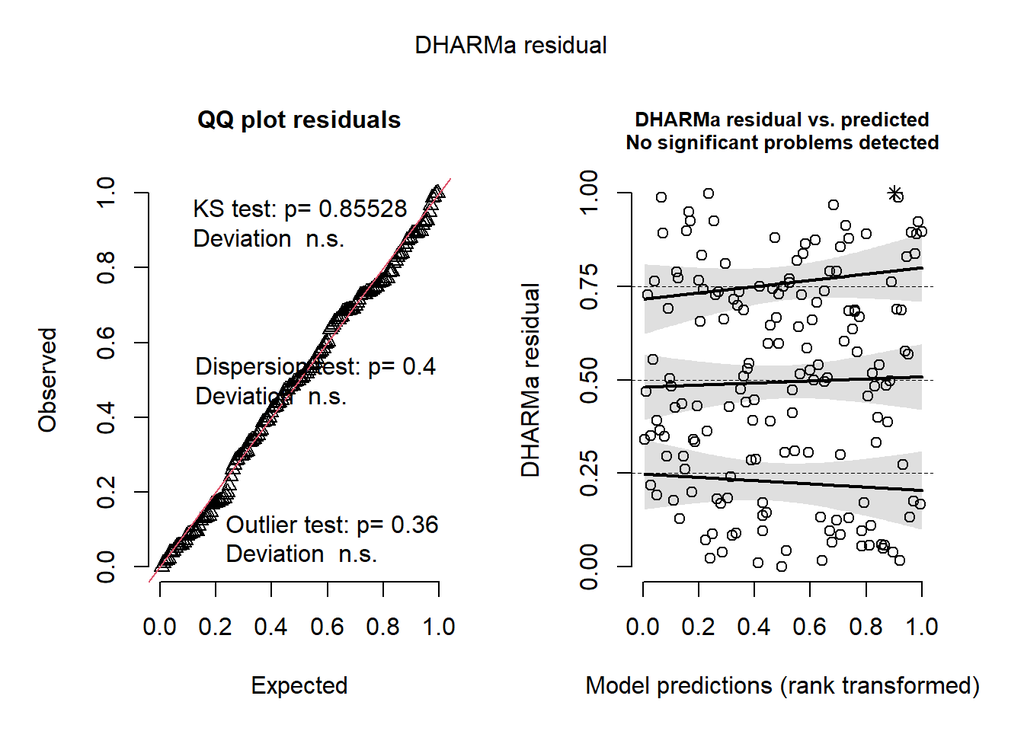

Plot prior and posterior densities of parameters

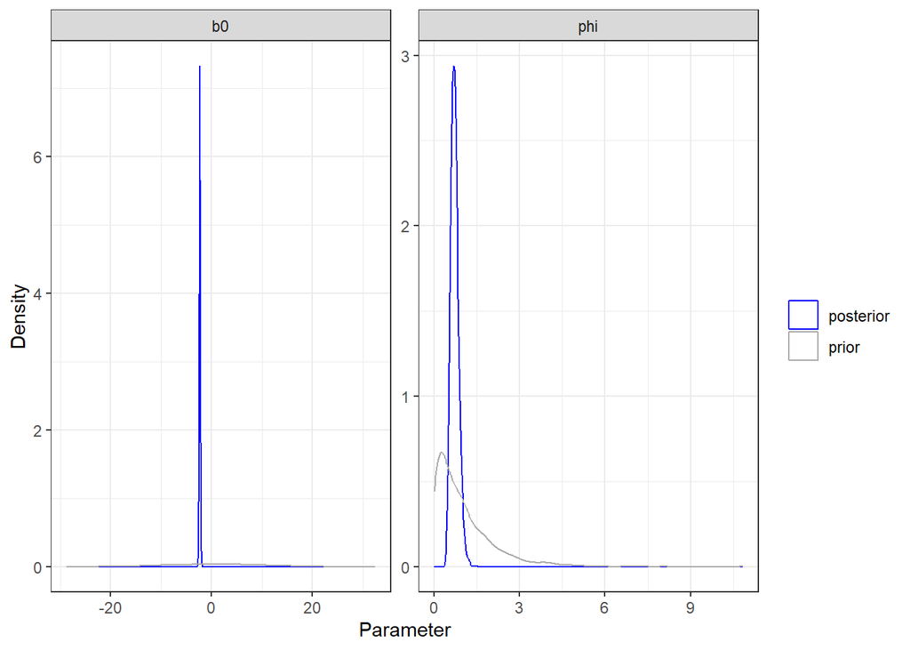

```r
plotPriorPosterior(stanSum,
                   stanObj,
                   useCode=useCode)
```

Plot prior and posterior draws of bycatch

```
## Ignoring unknown labels:
## • colour : ""
## Ignoring unknown labels:
## • colour : ""
```

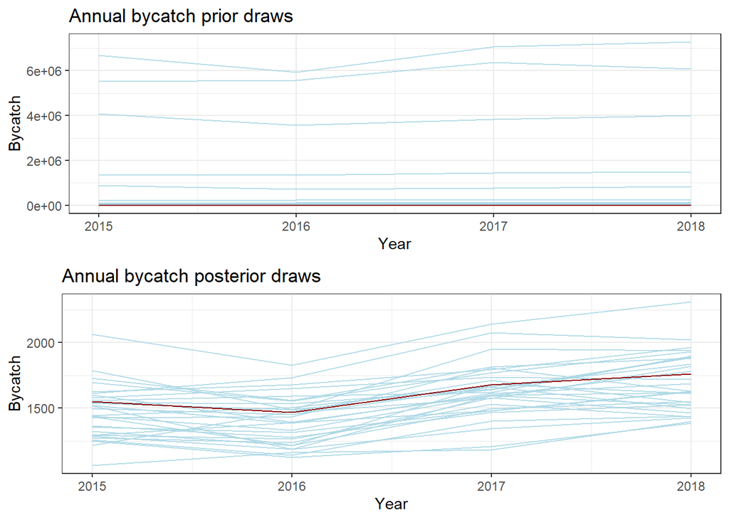

```r
plotPriorPosteriorSims(stanSum=stanSum,
                       modelNum=modelNum,
                       stanObj=stanObj,
                       setupObj=setupObj,
                       modeledEffort = FALSE,
                       effortSD = NULL,
                       useCode=useCode)
```

Convergence diagnostics

```r
getConvergence(stanObj,
               useCode=useCode)
```

```
## $num_divergent
## [1] 0 0 0 0
##
## $num_max_treedepth
## [1] 0 0 0 0
##
## $ebfmi
## [1] 0.9968662 1.0803504 1.0580046 1.2226803
```

Parameter summary table

```r
getSummary(stanSum,
           stanObj,
           modelNum,
           setupObj,
           spNum=1,
           useCode=useCode)
```

```
## # A tibble: 2 × 10
##   variable   mean median    sd   mad     q5    q95  rhat ess_bulk ess_tail
##   <chr>     <dbl>  <dbl> <dbl> <dbl>  <dbl>  <dbl> <dbl>    <dbl>    <dbl>
## 1 phi       0.726  0.713 0.137 0.132  0.530  0.972 1.00     2850.    2430.
## 2 b0       -2.36  -2.36  0.116 0.115 -2.55  -2.17  1.000    3005.    2185.
```

### Modeling probability of mortality

Code to run survival/mortality model.

With simulated survival data (arbitrary values). If there are any numerical variables, they need to be standardized using the mean and sd from the observer data for consistency. This data has year as a category, so standardization is not needed.

```r
mortData<-SimulatedMortality
```

Run multiple models to get the best one. Doesn’t calculate predicted probability of survival (predictP=FALSE)

```r
modelsToRun=c("y~1","y~Species","y~Year","y~Year+Species")
MortResults<-mortalityStan(mortData=mortData,
                          predData = NULL,
                          modelsToRun=modelsToRun,
                          factorVariables=c("Species","Year"),
                          numericVariables=NA,
                          mortalityColumn="dead",
                          outDir=getwd(),
                          runName="Simulated",
                          predictP=FALSE,
                          useCode=useCode
)
```

```
## Running MCMC with 4 chains, at most 8 in parallel...
##
## Chain 1 finished in 0.5 seconds.
## Chain 2 finished in 0.5 seconds.
## Chain 3 finished in 0.5 seconds.
## Chain 4 finished in 0.5 seconds.
##
## All 4 chains finished successfully.
## Mean chain execution time: 0.5 seconds.
## Total execution time: 0.8 seconds.
##
## Running MCMC with 4 chains, at most 8 in parallel...
##
## Chain 1 finished in 0.5 seconds.
## Chain 2 finished in 0.5 seconds.
## Chain 3 finished in 0.5 seconds.
## Chain 4 finished in 0.5 seconds.
##
## All 4 chains finished successfully.
## Mean chain execution time: 0.5 seconds.
## Total execution time: 0.7 seconds.
##
## Running MCMC with 4 chains, at most 8 in parallel...
##
## Chain 1 finished in 0.4 seconds.
## Chain 2 finished in 0.4 seconds.
## Chain 3 finished in 0.4 seconds.
## Chain 4 finished in 0.4 seconds.
##
## All 4 chains finished successfully.
## Mean chain execution time: 0.4 seconds.
## Total execution time: 0.5 seconds.
##
## Running MCMC with 4 chains, at most 8 in parallel...
##
## Chain 1 finished in 0.5 seconds.
## Chain 2 finished in 0.4 seconds.
## Chain 3 finished in 0.4 seconds.
## Chain 4 finished in 0.5 seconds.
##
## All 4 chains finished successfully.
## Mean chain execution time: 0.4 seconds.
## Total execution time: 0.7 seconds.
```

The outputs include the model selection and diagnostics tables.

```r
MortResults$waictab
```

```
## # A tibble: 4 × 7
##   Model           waic looic numHighK    maxK Dwaic Dlooic
##   <chr>          <dbl> <dbl>    <dbl>   <dbl> <dbl>  <dbl>
## 1 y~1             115.  115.        0 -0.0183  0      0
## 2 y~Species       116.  116.        0  0.115   1.76   1.77
## 3 y~Year          117.  117.        0  0.422   2.47   2.65
## 4 y~Year+Species  119.  119.        0  0.426   4.13   4.32
```

```r
MortResults$diagTable
```

```
## # A tibble: 12 × 11
##    Model       Parameter   mean median    sd   mad     q5     q95  rhat ess_bulk
##    <chr>       <chr>      <dbl>  <dbl> <dbl> <dbl>  <dbl>   <dbl> <dbl>    <dbl>
##  1 y~1         b[1]      -2.28  -2.27  0.258 0.258 -2.71  -1.88    1.00    1603.
##  2 y~Species   b[1]      -2.46  -2.44  0.403 0.401 -3.17  -1.85    1.00    1404.
##  3 y~Species   b[2]       0.298  0.276 0.524 0.521 -0.549  1.18    1.00    1295.
##  4 y~Year      b[1]      -1.61  -1.59  0.389 0.382 -2.27  -0.997   1.00    2392.
##  5 y~Year      b[2]      -1.15  -1.11  0.726 0.710 -2.41  -0.0121  1.00    2620.
##  6 y~Year      b[3]      -1.00  -0.960 0.757 0.714 -2.29   0.177   1.00    2566.
##  7 y~Year      b[4]      -1.32  -1.30  0.725 0.720 -2.54  -0.200   1.00    2789.
##  8 y~Year+Spe… b[1]      -1.84  -1.83  0.497 0.482 -2.68  -1.04    1.00    2036.
##  9 y~Year+Spe… b[2]      -1.13  -1.10  0.739 0.719 -2.41   0.0116  1.00    2405.
## 10 y~Year+Spe… b[3]      -0.948 -0.914 0.736 0.708 -2.19   0.226   1.00    2468.
## 11 y~Year+Spe… b[4]      -1.36  -1.32  0.743 0.706 -2.64  -0.192   1.00    2540.
## 12 y~Year+Spe… b[5]       0.383  0.393 0.545 0.535 -0.526  1.26    1.00    2471.
## # ℹ 1 more variable: ess_tail <dbl>
```

```r
mortModelNum<-which(MortResults$waictab$Dwaic==0)
```

This function will give posterior predictive checks for the probability model.

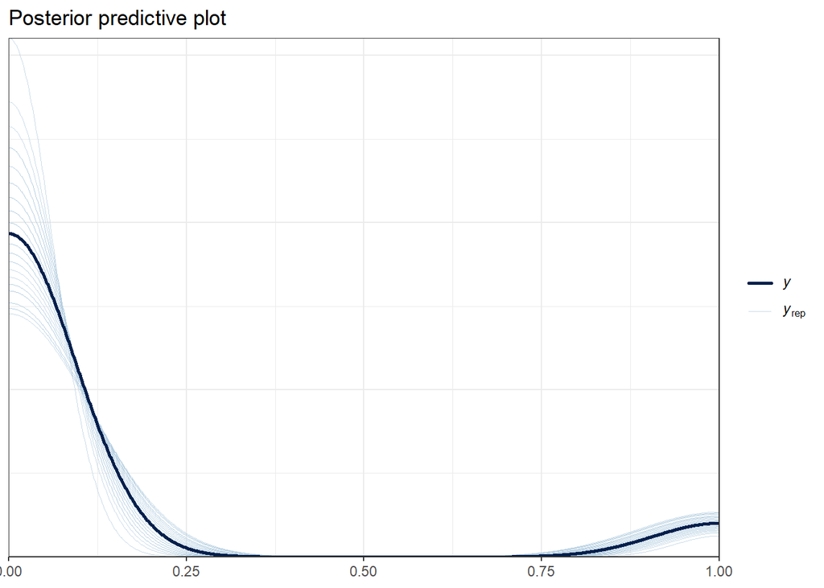

```r
plotPPCMortality(y=mortData$dead,
                       modelNum=1,
                       mortalityStanList=MortResults$stanRuns,
                       useCode=useCode)
```

With predictions for each year for BUM, best model only

```r
predData<-obsdat %>%
  distinct(Year)%>%
  mutate(Species="BUM")
predData
```

```
## # A tibble: 4 × 2
##    Year Species
##   <dbl> <chr>
## 1  2015 BUM
## 2  2016 BUM
## 3  2017 BUM
## 4  2018 BUM
```

```r
MortResultsP<-mortalityStan(mortData=mortData,
                           predData = predData,
                           modelsToRun=modelsToRun[mortModelNum],
                           factorVariables=c("Species","Year"),
                           numericVariables=NA,
                           mortalityColumn="dead",
                           outDir=getwd(),
                           runName="Simulated",
                           predictP=TRUE,
                           useCode=useCode
)
```

```
## Running MCMC with 4 chains, at most 8 in parallel...
##
## Chain 1 finished in 0.3 seconds.
## Chain 2 finished in 0.3 seconds.
## Chain 3 finished in 0.3 seconds.
## Chain 4 finished in 0.3 seconds.
##
## All 4 chains finished successfully.
## Mean chain execution time: 0.3 seconds.
## Total execution time: 0.5 seconds.
```

### Calculating bycatch mortality

Combine mortality and bycatch estimate to get bycatch mortality or survival

Estimates total bycatch mortality

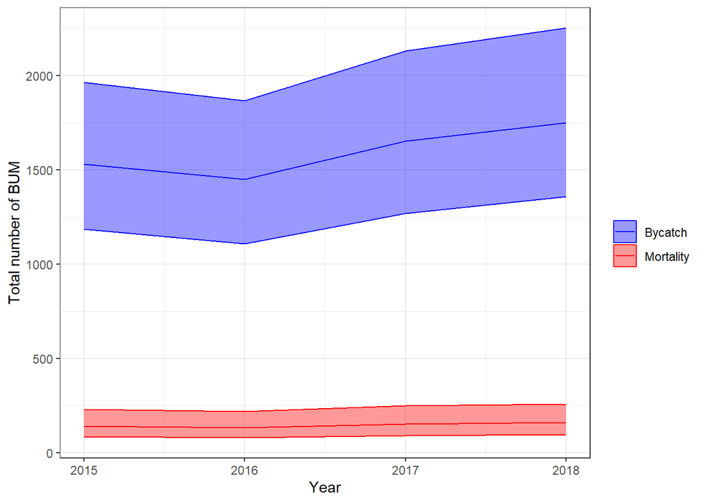

```r
mortalityEsts<-getMortPred(stanSum=stanSum,
                           modelNum=which(stanSum$waictab$Dwaic==0),
                           stanObj=stanObj,
                           Species="BUM",
                           setupObj=setupObj,
                           modeledEffort = FALSE,
                           effortSD = NULL,
                           useCode=useCode,
                           mortResults=MortResultsP,
                          mortModelNum=1)

plotMortalityFunc(mortalityEsts,Species="BUM")
```

```r
head(mortalityEsts)
```

```
## # A tibble: 6 × 7
## # Groups:   Year [2]
##    Year Outcome          mean       se     lower    upper    median
##   <dbl> <chr>           <dbl>    <dbl>     <dbl>    <dbl>     <dbl>
## 1  2015 Bycatch     1539.     201.     1184.     1962.    1528.
## 2  2015 Mortality    145.      38.0      84.4     228.     140.
## 3  2015 Probability    0.0943   0.0210    0.0583    0.139    0.0929
## 4  2016 Bycatch     1461.     193.     1107      1866.    1450
## 5  2016 Mortality    138.      36.2      80.2     218.     133.
## 6  2016 Probability    0.0943   0.0210    0.0583    0.139    0.0929
```

### References

Gabry, Jonah, Rok Češnovar, Andrew Johnson, and Steve Bronder. 2025. *Cmdstanr: R Interface to ’CmdStan’*. https://mc-stan.org/cmdstanr/.

Stan Development Team. 2025. *RStan: The R Interface to Stan*. https://mc-stan.org/.